# Sebastian Silas

Data Scientist | Programmer | Lead Lecturer | PhD Researcher

Neues Haus 1, 30175 Hannover

| +44 7917 343 060 | sebsilas.com | sebsilas@gmail.com | sebsilas |

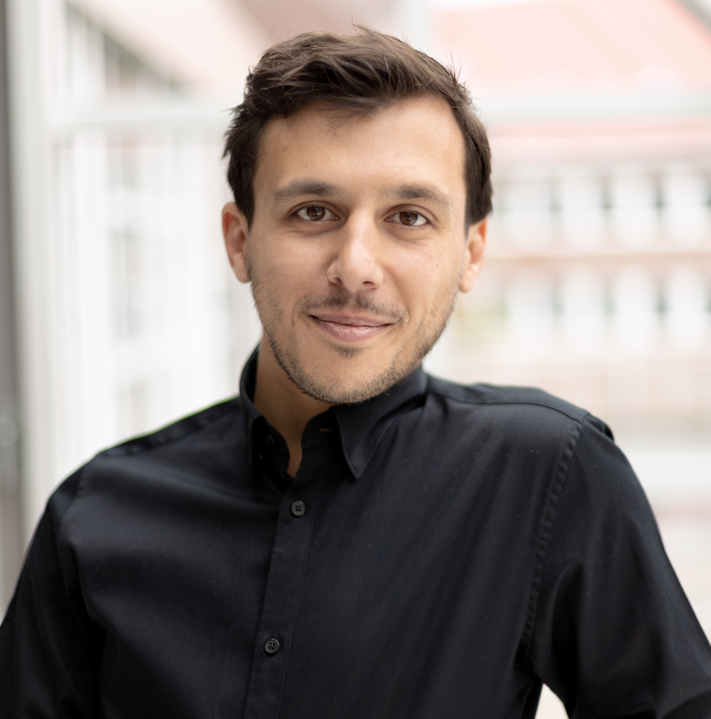

## Freelance Programming and Data Science Consultant Work (2020-Present)

`2023` **Programmer** (Max Planck Institute)

- Creation of Rhythm Tapping Test and adaption of singing test for children populations.

`2023` **Data Scientist, Programmer** (ABCD Study)

- Development of new gamified test infrastructure for the largest long-term study of brain development and child health in the United States, the ABCD Study.

`2021` **Programmer** (AIRs Singing Project, University of Prince-Edward Island)

- Development of a new generation test infrastructure for AIRs Singing Project, following the development of singing abilities in teenage and adult populations.

`2021` **Programmer** (Western Sydney University)

- Programming tutorial preparation to help researchers implement psychological tests easily.

## Current Roles

`2023-present` **Project Manager, Data Scientist, Programmer** (Diaes4All Project, University of Tübingen)

- Co-managing research project and building technical architecture to track users’ learning of musical items over the long-term using statistical modelling and web APIs.

`2022-present` **Data Scientist** (SoundOut/DataZ)

- Working in the field of sonic branding and using DevOps/MLOps, R, Python, Amazon Web Services, machine learning, and related skills to deliver a wide range of practical solutions.

`2022-present` **Lead Lecturer, Psychology of Music** (BIMM University, London)

- Designed and maintain a new Psychology of Music course which runs one semester per year.

`2020-present` **PhD Researcher** (Hochschule für Musik, Theater und Medien, Hannover)

- Project: Learning to Play By Ear in the 21st Century: A Computational Approach To Acquiring New Melodic Representations

## Previous Roles

`2022` **Research Scientist** (Goldsmiths University)

- Research Scientist on Innovate UK-funded project responsible for analyzing large datasets and producing three academic manuscripts.

`2017-2023` **Company Director, Tutor of Saxophone and Piano** (Hop Music, London)

- Co-founded company in South East London employing several music teachers and working as a tutor. Day-to-day managing of lesson scheduling and company management.

## Awards

`06/2022 – 03/2024` **Studienstiftung des deutschen Volkes PhD Scholarship** (52,200 €)

`12/2020 – 12/2021` **DAAD PhD Scholarship** (14,935 €)

- 1-year doctoral scholarship granted to talented researchers. The DAAD (German Academic Exchange Service) is the world’s largest funding organisation for the international exchange of students and researchers: https://www.daad.de/.

## Education

`2019 – 2020` **Goldsmiths University, London** Computational Cognitive Neuroscience, MSc (First class honours)

- Thesis: “Predicting production from dirty data: Psychometric and Big Data approaches to melodic production

`2016 – 2019` **Goldsmiths University, London** Psychology with Cognitive Neuroscience, BSc (First class honours)

- Thesis: “Does musical training improve general working memory? A causal modelling approach to the associations between general working memory, musical working memory and musical training.

`2011 – 2014` **Middlesex University, London** Music (Jazz Saxophone Performance), BA (Upper second-class honours)

## Publications

1.

Silas, S., Müllensiefen, D., & Kopiez, R. (2023). Singing ability assessment: Development and validation of a singing test based on item response theory and a general open-source software environment for singing data. *Behaviour Research Methods*. https://doi.org/10.3758/s13428-023-02188-0

2.

Silas, S., & Müllensiefen, D. (2023). Learning and recalling melodies: A computational investigation using the melodic recall paradigm. *Music Perception*.

3.

Silas, S., Baker, D., Sachet, A., & Müllensiefen, D. (2023). Discovering emotional-semantic representations for sonic branding: A data-driven approach. *In Prep.*

4.

Silas, S., Robinson, M., Baker, D., Müllensiefen, D., Harrison, P., & Jacoby, N. (2023). The recall-recognition paradox? A multi-paradigm approach to exploring the memorability of sonic logos. *In Prep.*

5.

Silas, S., Müllensiefen, D., Gelding, R., Frieler, K., & Harrison, P. M. C. (2022). The associations between music training, musical working memory, and visuospatial working memory: An opportunity for causal modeling. *Music Perception*, *39*(4), 401–420. https://doi.org/10.1525/mp.2022.39.4.401

6.

Tsigeman, E., Silas, S., Frieler, K., Likhanov, M., Gelding, R., Kovas, Y., & Müllensiefen, D. (2022). The jack and jill adaptive working memory task: Construction, calibration and validation. *PloS One*, *17*(1), e0262200. https://doi.org/10.1371/journal.pone.0262200

7.

Gelding, R. W., Harrison, P. M. C., Silas, S., Johnson, B. W., Thompson, W. F., & Müllensiefen, D. (2021). An efficient and adaptive test of auditory mental imagery. *Psychological Research*, *85*(3), 1201–1220. https://doi.org/10.1007/s00426-020-01322-3

## Conferences

1.

Silas, S., Müllensiefen, D., & Kopiez, R. (2023). *Utilising a new generation of musical production tests to understand musical learning: Singing ability assessment, melodic recall and playing by ear.* Deutsche gesellschaft für musikpsychologie.

2.

Silas, S., & Frieler, K. (2023). *The musicassessr ecosystem: Record, measure, score and present feedback about musical production behaviour in real-time, supported by psychometric models.* Deutsche gesellschaft für musikpsychologie.

3.

Silas, S. (2023). *Adaptive training: A system for longitudinal research on music learning.* LongGold workshop. https://www.youtube.com/watch?v=gwro_UWAbTw

4.

Silas, S. (2023). *Make it fun! Gamifying music listening tests.* LongGold workshop. https://www.youtube.com/watch?v=dmDrZg0R0ZU

5.

Silas, S., Baker, D., & Müllensiefen, D. (2022). *Changing the emotional-semantic perception of visual scenes with music: A large-scale investigation into the effects of audio branding.* Deutsche gesellschaft für musikpsychologie.

6.

Silas, S., Kopiez, R., & Müllensiefen, D. (2021). *What makes playing by ear difficult?* SEMPRE conference.

7.

Silas, S. (2021). *Construction and validation of the melody singing task using explanatory item response theory modelling*. ESCOM. https://youtu.be/_sorkoH7qSA

8.

Silas, S., Müllensiefen, D., Gelding, R., Harrison, P., & Frieler, K. (2019). *Does musical training improve general working memory? A causal modelling approach to the associations between general working memory, musical working memory and musical training*. Deutsche gesellschaft für musikpsychologie.